# Sesion 15 - Selección de Variables Parte 2/3

Juan Carlos Martínez-Ovando

Maestría en Ciencia de Datos

Primavera 2019

# 1 Seleccion estocastica de variables

## 1.1 Especificacion

## 1.2 Datos

En estas notas ilustramos el procedimiento de **seleccion estocastica de variables** (SSVS por sus siglas en ingles) en el contexto de un modelo lineal generalizado probit.

Los datos corresponden a los de un estudio de identificación de nacimientos prematuros relacionados con la administración de un medicamento general, denotado por `dde`. La asociacion de la identificación de `nacimiento prematuro` y `nacimiento en tiempo`, denotado por la variable $y$, la variable `dde` esta definida bajo la presencia de variables auxiliares, denotadas por cinco variables adicionales (discretas y categoricas).

Asi, empleamos la siguiente notacion:

- $y \in \{0,1\}$, siendo $1$ si el nacimiento fue `prematuro` y $0$ para el otro caso,
- $x$ representa el nivel/dosis administrada del medicamento `dde`
- $w_1, \ldots, w_5$ - covariables adicionales.

Mostramos los datos a continuacion:

```r
if(!require('mvtnorm')){install.packages("mvtnorm")}
library("mvtnorm")

dde <- read.csv('est46114_s16.csv',
                header = TRUE, sep = ",",
                quote="\"", dec=".", fill = TRUE)
head(dde)
```

```
##    x y         w1         w2        w3         w4 w5
## 1 25 0  2.2122960  1.0629606 0.4492115  0.5008197  1
## 2 16 0 -2.1682485 -0.3629391 0.6118405  1.6912562  1
## 3 55 1  0.5320872  0.8628344 1.0997276 -0.6006762  0
## 4 15 0 -1.0731124 -0.3379233 1.4249857  0.4711728  0
## 5 34 0  0.5620909 -0.1002734 0.6118405  0.7836054  1
## 6 23 0  1.2221729  1.4632132 0.4492115 -0.8059239  0
```

```r
dim(dde)
```

```
## [1] 2380    7
```

```r
summary(dde)
```

```
##        x                y                w1                 w2
##  Min.   :  2.00   Min.   :0.0000   Min.   :-2.73832   Min.   :-1.9765
##  1st Qu.: 17.00   1st Qu.:0.0000   1st Qu.:-0.63806   1st Qu.:-0.6881
##  Median : 25.00   Median :0.0000   Median :-0.08299   Median :-0.1753
##  Mean   : 30.18   Mean   :0.1517   Mean   : 0.00000   Mean   : 0.0000
##  3rd Qu.: 36.25   3rd Qu.:0.0000   3rd Qu.: 0.54709   3rd Qu.: 0.4751
##  Max.   :178.00   Max.   :1.0000   Max.   : 8.96313   Max.   :12.2575
##        w3                w4                w5
##  Min.   :-1.8276   Min.   :-2.1560   Min.   :0.0000
##  1st Qu.:-0.6892   1st Qu.:-0.6600   1st Qu.:0.0000
##  Median :-0.2013   Median :-0.2335   Median :0.0000
##  Mean   : 0.0000   Mean   : 0.0000   Mean   :0.4424
##  3rd Qu.: 0.6118   3rd Qu.: 0.4256   3rd Qu.:1.0000
##  Max.   : 3.3765   Max.   : 7.3880   Max.   :1.0000
```

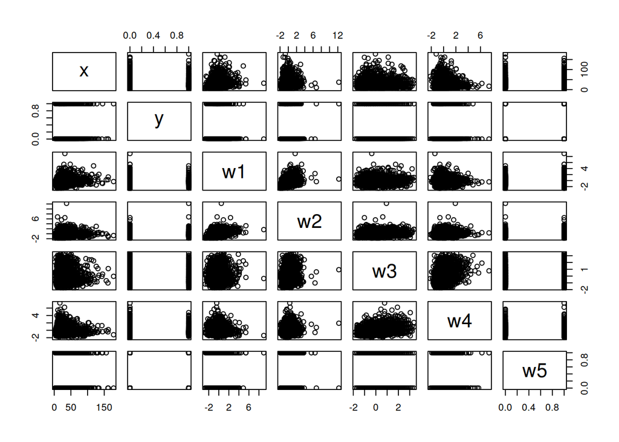

```r
plot(dde)
```

## 1.3 Estanzarizacion

Y su version **estandarizada** para `dde`,

```r
dde$x<- (dde$x - mean(dde$x))/sqrt(var(dde$x))
summary(dde)
```

```
##        x                 y                w1                 w2
##  Min.   :-1.4174   Min.   :0.0000   Min.   :-2.73832   Min.   :-1.9765
##  1st Qu.:-0.6629   1st Qu.:0.0000   1st Qu.:-0.63806   1st Qu.:-0.6881
##  Median :-0.2605   Median :0.0000   Median :-0.08299   Median :-0.1753
##  Mean   : 0.0000   Mean   :0.1517   Mean   : 0.00000   Mean   : 0.0000
##  3rd Qu.: 0.3054   3rd Qu.:0.0000   3rd Qu.: 0.54709   3rd Qu.: 0.4751
##  Max.   : 7.4354   Max.   :1.0000   Max.   : 8.96313   Max.   :12.2575
##        w3                w4                w5
##  Min.   :-1.8276   Min.   :-2.1560   Min.   :0.0000
##  1st Qu.:-0.6892   1st Qu.:-0.6600   1st Qu.:0.0000
##  Median :-0.2013   Median :-0.2335   Median :0.0000
##  Mean   : 0.0000   Mean   : 0.0000   Mean   :0.4424
##  3rd Qu.: 0.6118   3rd Qu.: 0.4256   3rd Qu.:1.0000
##  Max.   : 3.3765   Max.   : 7.3880   Max.   :1.0000
```

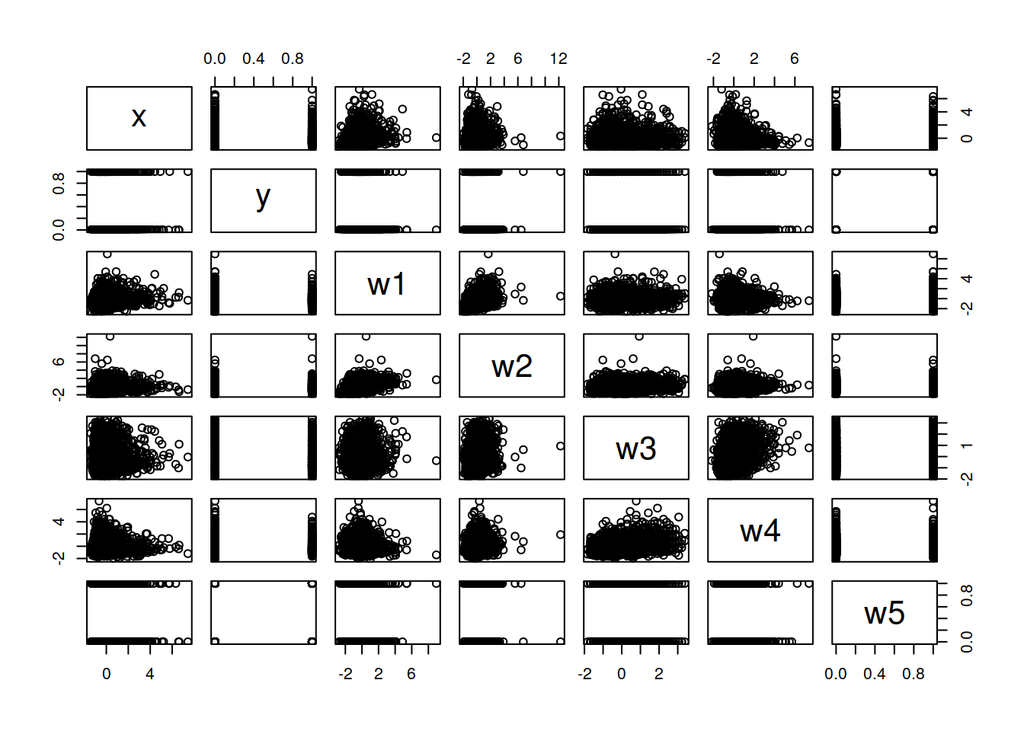

```r
plot(dde)
```

# 2 Modelo

El modelo que consideramos es **probit lineal**, el cual relaciona la probabilidad del evento $\{Y=1\}$ con las covariables condicionales $w=(x,z_1,\ldots,z_5)$, como
$$\mathbb{P}\left(Y_i=1|w_i\right)=\Phi\left(\beta'w_i\right),$$
para $i=1,\ldots,n$, donde,

- $\Phi(\cdot)=N(\cdot|0,1)$ es la funcion de distribucion (acumulacion de probabilidades) de la distribucion gaussiana, y
- $\beta=(\beta_x,\beta_1,\ldots,\beta_5)$ es el vector de coeficientes de regresion.

> Como vimos en clase, el modelo puede expresarse de manrea extendida empleando variables latentes.

En particular, se introduce al modelo la variable latente $Z$ que sirve como elemento conector de $\beta'w$ y $\Phi$. Así, el modelo queda expresado como

$$\begin{eqnarray}
Y_i|Z_i & \sim & Ber\left(\cdot|\theta=Pr(Z_i > 0)\right) \\
Z_i|w_i & \sim & N(z|\beta'w_i,1),
\end{eqnarray}$$
para $i=1,\ldots,n$.

El modelo anterior, incluyendo las variables latentes $Z_i$s, es lineal en los coeficientes de regresion $\beta$, aunque su estimacion no es una tarea sencilla.

A continuacion presentamos dos versiones para su estimacion:

- frecuentista y
- bayesiana.

# 3 Implementacion del modelo saturado

## 3.1 Analisis frecuentista

En este caso, se puede obtener un estimador de $\beta$ basada en la maximizacion de la verosimilitud extendida,

$$lik\left(\beta,(z_i)_{i=1}^n|datos\right) = \prod_{i=1}^{n} Ber\left(y_i|\theta=Pr(z_i > 0)\right)N(z_i|\beta'w_i,1).$$

```r
X <- cbind(1, dde$x,dde$w1,dde$w2,dde$w3,dde$w4,dde$w5)
Y <- dde$y
dde_mle <- glm(Y ~ -1+X, family=binomial("probit"))
summary(dde_mle)
```

```
##
## Call:
## glm(formula = Y ~ -1 + X, family = binomial("probit"))
##
## Deviance Residuals:
##     Min       1Q   Median       3Q      Max
## -1.3854  -0.5952  -0.5208  -0.4496   2.3678
##
## Coefficients:
##    Estimate Std. Error z value Pr(>|z|)
## X1 -1.08068    0.04355 -24.816  < 2e-16 ***
## X2  0.17536    0.02909   6.028 1.67e-09 ***
## X3 -0.12817    0.03528  -3.633 0.000280 ***
## X4  0.11097    0.03366   3.297 0.000978 ***
## X5 -0.01705    0.03405  -0.501 0.616659
## X6 -0.08216    0.03576  -2.298 0.021571 *
## X7  0.05462    0.06473   0.844 0.398721
## ---
## Signif. codes:  0 '***' 0.001 '**' 0.01 '*' 0.05 '.' 0.1 ' ' 1
##
## (Dispersion parameter for binomial family taken to be 1)
##
##     Null deviance: 3299.4  on 2380  degrees of freedom
## Residual deviance: 1966.9  on 2373  degrees of freedom
## AIC: 1980.9
##
## Number of Fisher Scoring iterations: 4
```

```r
betamle <- dde_mle$coef
betamle
```

```
##          X1          X2          X3          X4          X5          X6
## -1.08067678  0.17536139 -0.12816564  0.11097063 -0.01704583 -0.08216299
##          X7
##  0.05462284
```

**Que pasaria si incorporamos un termino constante en el predictor lineal?**

## 3.2 Analisis bayesiano

En el contexto bayesiano, el `modelo` que describimos anteriormente se complementa con la distribucion sobre nuestro nivel de creencia entorno a los valores plausibles de $\beta$, i.e. la distribucion inicial sobre $\beta$. Dada la linealidad parcial envolucrada en el perdictor lineal, la distribucion inicial es usualmente especificada como una distribucion normal $p$-variada,
$$\pi(\beta) = N_p(\beta|m_0,S_0),$$
donde

- $m_0$ es el vector inicial esperado de los coeficientes de regresion, y
- S_0$ denota la covariabilidad de tales coeficientes.

En la practica, es comun especificar $m_0$ y $S_0$ de dos formas:

1. manera *empirica* (i.e. empleando la informacion de los datos a traves de procedimientos basados en **empirical bayes**, empleando la media y dispersion empírica), o
2. manera **difusa**, de la siguiente forma:

```r
beta0 <- rep(0,7)
beta0
```

```
## [1] 0 0 0 0 0 0 0
```

```r
Pbeta0 <- 0.25*diag(7)
Pbeta0
```

```
##      [,1] [,2] [,3] [,4] [,5] [,6] [,7]
## [1,] 0.25 0.00 0.00 0.00 0.00 0.00 0.00
## [2,] 0.00 0.25 0.00 0.00 0.00 0.00 0.00
## [3,] 0.00 0.00 0.25 0.00 0.00 0.00 0.00
## [4,] 0.00 0.00 0.00 0.25 0.00 0.00 0.00
## [5,] 0.00 0.00 0.00 0.00 0.25 0.00 0.00
## [6,] 0.00 0.00 0.00 0.00 0.00 0.25 0.00
## [7,] 0.00 0.00 0.00 0.00 0.00 0.00 0.25
```

### 3.2.1 Algoritmo MCMC

La distribución final o posterior para el modelo anterior no puede obtenerse de manera analitica cerrada. *Esto es porque el modelo no es conjugado para los parametros, ademas de ser no lineal de manera estructural integrada.*

La inferencia, al igual que el caso frecuentista, descansa en la implementacion de metodos numericos. En particular, algoritmos *Markov Chain Monte Carlo* (MCMC).

Ilustramos la implementacion de estos metodos con el algoritmo *Gibbs sampler*, en el cual se simula una sucesion de parametros y variables latentes simuladas,
$$\left\{\beta^{(m)},(z_i^{(m)})_{i=1}^n\right\}_{m\geq 1},$$
la cual tiene como distribucion invariante la distribucion final del modelo,
$$\pi\left(\beta,(z_i)_{i=1}^n|datos\right) \propto \left\{\prod_{i=1}^{n} Ber\left(y_i|\theta=Pr(z_i > 0)\right)N(z_i|\beta'w_i,1) \right\} N(\beta|m_0,S_0).$$
El procedimiento opera como un procedimiento iterativo, fijando:

```r
beta <- rep(0,7)
n <- nrow(dde)
z <- rep(0,n)
G <- 5000
```

Asi, para las iteraciones $m=1,\ldots,M$, se sigue
$$\beta^{(m)}|(z_i^{(m-1)})_{i=1}^n,\text{datos} \sim \pi\left(\beta|(z^{(m-1)}_i)_{i=1}^n,\text{datos}\right),$$
y
$$(z_i^{(m)})_{i=1}^n |\beta^{(m)}, \text{datos} \sim \pi\left((z^_i)_{i=1}^n|\beta^{(m)},\text{datos}\right).$$

```r
#       Gibbs sampler
gt <- 1
for(gt in 1:G){
  eta<- X%*%beta    # Predictor lineal (variable auxiliar)

  # Muestreo de la distribucion truncada para Z
  # de las distribuciones condicionales completas
  z[Y==0] <- qnorm(runif(sum(1-Y), 0,pnorm(0,eta[Y==0],1)), eta[Y==0],1)
  z[Y==1] <- qnorm(runif(sum(Y), pnorm(0,eta[Y==1],1),1), eta[Y==1],1)

  # Muestreo de la distribucion final completa para beta
  Vbeta <- solve(Pbeta0 + t(X)%*%X)
  Ebeta <- Vbeta%*%(Pbeta0%*%beta0 + t(X)%*%z)
  beta <- c(rmvnorm(1,Ebeta,Vbeta))

  # Output
  write(t(beta),file='EST46114_SSVS_beta.out', ncol=7, append=T)
  #print(c(gt,round(beta*100)/100))
}
```

### 3.2.2 Monitoreo

Trace-plots para `beta[1]` y `beta[2]`

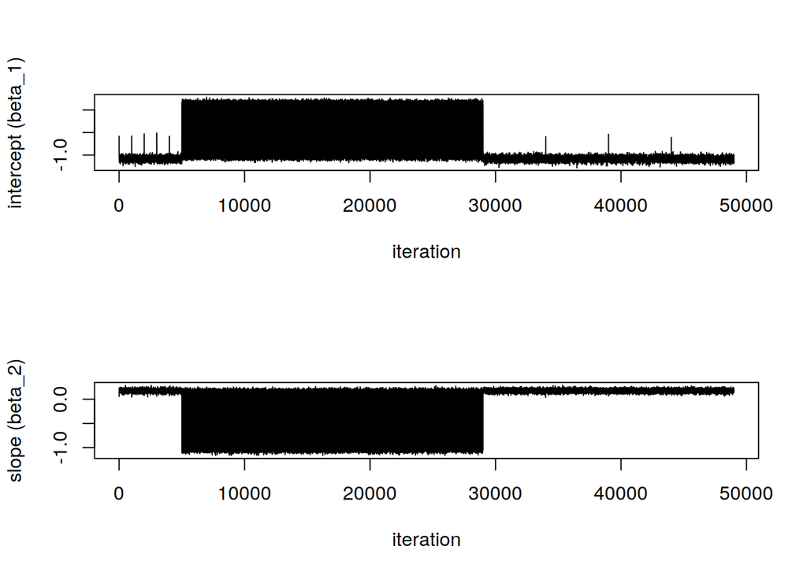

```r
par(mfrow=c(2,1))
beta_out<- matrix(scan('EST46114_SSVS_beta.out'), ncol=7, byrow=T)
plot(beta_out[,1],type="l",xlab="iteration",
        ylab="intercept (beta_1)")
plot(beta_out[,2],type="l",xlab="iteration",ylab="slope (beta_2)")
```

**Distribucion final marginal para el coeficiente de pendiente de** `DDE`

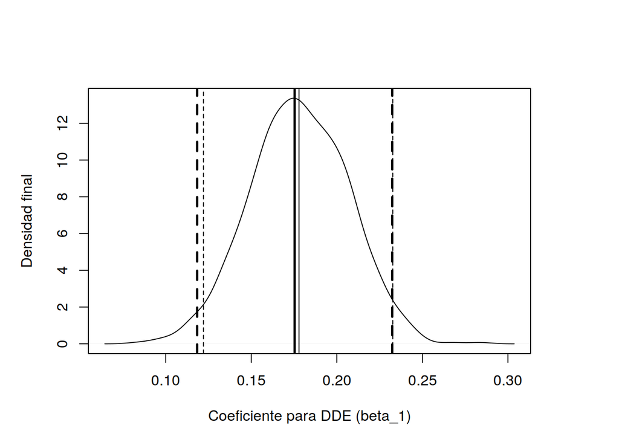

```r
slp <- beta_out[101:1000,2]
par(mfrow=c(1,1))
par(mar=c(5,5,5,5))
plot(density(slp),type="l",xlab="Coeficiente para DDE (beta_1)",ylab="Densidad final",
     cex=1.2, main="")
abline(v=mean(slp))
abline(v=0.17536139,lwd=2.5) # MLE
abline(v=0.17536139 + 1.96*0.02909*c(-1,1),lwd=2.5,lty=2)
abline(v=quantile(slp,probs=c(0.025,0.975)),lty=2)
```

## 3.3 Resultados

**Curva de respuesta a dosis** `DDE` **para nacimiento prematuro.**

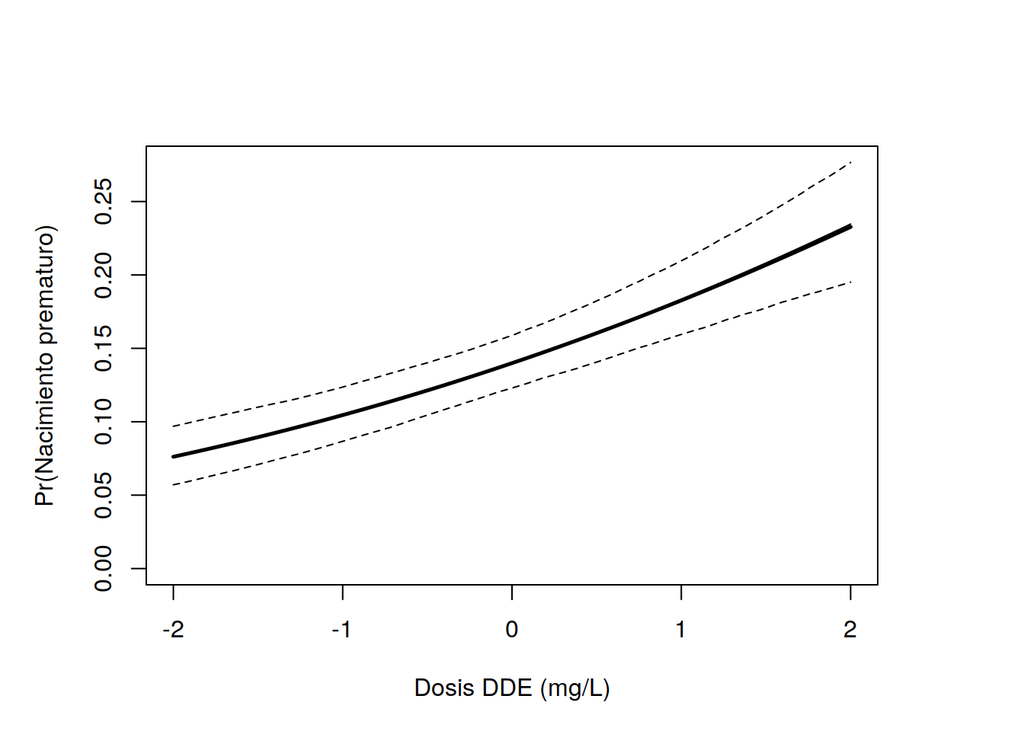

```r
par(mfrow=c(1,1))
par(mar=c(5,5,5,5))
xg<- seq(-2,2,length=100)
beta<- beta_out[101:1000,]  # Datos sin periodo de calentamiento
post<- matrix(0,100,4)
for(i in 1:100){
  post[i,1]<- mean(pnorm(beta[,1] + xg[i]*beta[,2]))
  post[i,2:3]<- quantile(pnorm(beta[,1] + xg[i]*beta[,2]),probs=c(0.025,0.975))
  post[i,4]<- pnorm(-1.08068 + xg[i]*0.17536139)
}
xtrue<- xg*sqrt(var(dde$x)) + mean(dde$x)
plot(xtrue,post[,1],xlab="Dosis DDE (mg/L)",ylab="Pr(Nacimiento prematuro)",cex=1.2,
     ylim=c(0,max(post)), type="l")
lines(xtrue,post[,2],lty=2)
lines(xtrue,post[,3],lty=2)
lines(xtrue,post[,4],lwd=2.5)
```

**Resumen de la distrinbucion final de los coeficientes de regresion**

```r
table1<- matrix(0,7,5)
for(i in 1:7){
  table1[i,]<- c(mean(beta[,i]),median(beta[,i]),sqrt(var(beta[,i])),
                 quantile(beta[,i],probs=c(0.025,0.975)))
}
table1 <- round(table1*100)/100
table1 <- as.data.frame(table1)
colnames(table1) <- c("Mean", "Median", "s.d.","q1","q2")
table1
```

```
##    Mean Median s.d.    q1    q2
## 1 -1.08  -1.08 0.04 -1.16 -1.00
## 2  0.18   0.18 0.03  0.12  0.23
## 3 -0.13  -0.13 0.04 -0.20 -0.06
## 4  0.11   0.11 0.03  0.04  0.18
## 5 -0.02  -0.02 0.03 -0.08  0.05
## 6 -0.08  -0.08 0.04 -0.15  0.00
## 7  0.05   0.06 0.06 -0.06  0.17
```

# 4 Seleccion estocastica de variables

## 4.1 Especificacion inicial

Recordemos, del `analisis frecuentista` con el `modelo saturado` que el estimador maximo verosimil es:

```r
ddemle <- glm(Y ~ -1+X, family=binomial("probit"))
betamle <- ddemle$coef
betamle
```

```
##          X1          X2          X3          X4          X5          X6
## -1.08067678  0.17536139 -0.12816564  0.11097063 -0.01704583 -0.08216299
##          X7
##  0.05462284
```

## 4.2 Alternativas

En el caso de seleccion de variables, se sigue que que algunas variables explicativas pueden ser excluidas debido a:

- **Redundancia de informacion**, debido a que esta puede estar conjuntamente relacionada con el resto de las variables explicativas (todas o un subconjunto de ellas), o
- **Ausencia de relación**, debido a que esta variable pueda no estar correlacionada con la variable de respuesta.

Inspeccionar las combianciones de estos dos escenarios puede ser altamente demandante tanto operativa como computacionalmente.

Los **metodos de regularizacion** como `ridge` y `lasso` permiten resolver este problema.

## 4.3 Metodo automatizado estocastico

Alternativamente, desde el punto de vista bayesiano, este problema puede resolverse explicitamente estableciendo un **metodo automatizado de seleccion de variables** (SSVS). Este procedimiento adopta una distribución inicial de la siguiente forma,
$$\pi(\beta) = \prod_{j=1}^{p}\pi(\beta_j),$$
donde

$$\pi(\beta_j)= \alpha \delta_{\{0\}}(\beta_j)+(1-\alpha)N(\beta_j|m_{j0},s_{j0}),$$

incluyendo el parametro $0 < \alpha < 1$ como la probabilidad de que $\beta_j=0$ (i.e., en este caso,la variable $x_j$ es irrelevante para el modelo y los datos).

En el siguiente script se extiende el *Gibbs sampler* del procedimiento estandar con la implementacion del procedimiento SSVS.

Los valores iniciales son:

```r
p <- ncol(X)
p
```

```
## [1] 7
```

```r
p0 <- rep(0.5,p)
b0 <- rep(0,p)
s0 <- rep(2,p)
```

## 4.4 Implementacion MCMC

Al igual que el modelo estatico, consideramos los siguientes `valores iniciales` de la cadena `MCMC`:

- $\beta^{(0)}$ se fija como el EMV de $\beta$, en este caso `betamle`
- $(z^{(0)}_i)_{i=1}^{n}$ se fija en $z=0$
- el numero de iteraciones de la cadena `MCMC` es `G<-5000`.

```r
beta <- betamle
n <- nrow(dde)
z <- rep(0,n)
G <- 5000
```

### 4.4.1 *Gibbs sampler*

El algoritmo se implementa iterativamente en la siguiente `script`.

```r
gt <- 1
for(gt in 1:G){
  #     Data augmentation step
  eta<- X%*%beta    # Predictor lineal

  # Muestreo de la distribucion normal truncada para latentes
  # de la distribucion condicional completa
  z[Y==0]<- qnorm(runif(sum(1-Y),0,pnorm(0,eta[Y==0],1)),eta[Y==0],1)
  z[Y==1]<- qnorm(runif(sum(Y),pnorm(0,eta[Y==1],1),1),eta[Y==1],1)

  # Actualizacion de coeficientes de regresion (uno a la vez, en lugar de por bloque como en el algoritmo anterior)
  j <-1
  for(j in 1:p){
    #   Varianza final condicional para beta_j bajo la distribucion inicial normal
    Vj<- 1/(s0[j]^{-2} + sum(X[,j]^2))
    Ej<- Vj*sum(X[,j]*(z-X[,-j]%*%beta[-j]))

      # Probabilidad condicional de incluir el predictor 'j'
    phat<- 1/(1 + p0[j]/(1-p0[j]) * dnorm(0,Ej,sqrt(Vj))/dnorm(0,b0[j],s0[j]) )
    m<- rbinom(1,1,phat)
    beta[j]<- m*rnorm(1,Ej,sqrt(Vj))
  }

  # Output
  write(t(beta),file='est46114_s16_beta_ss.out', ncol=7, append=T)
  #print(c(gt,round(beta*100)/100))
}
```

### 4.4.2 Monitoreo

Las graficas de trayectorias las monitoreamos de la siguiente forma:

```r
beta <- matrix(scan('est46114_s16_beta_ss.out'), ncol=7, byrow=T)
dim(beta)
```

```
## [1] 10000     7
```

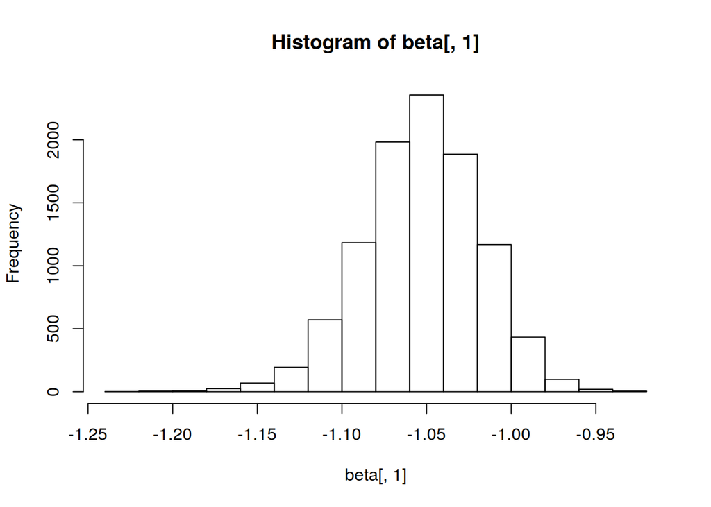

```r
hist(beta[,1])
```

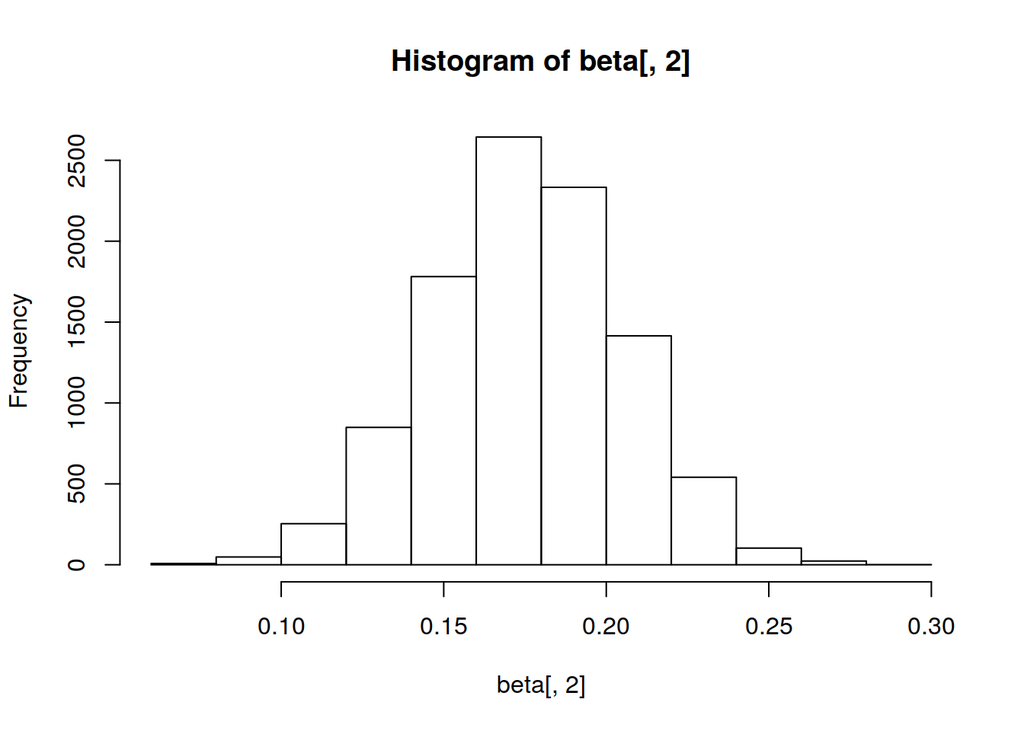

```r
hist(beta[,2])
```

En general, hay $2^p$ numero de posibles modelos. Y en nuestro caso particular, estos son $2^p = 2^7 = 128$.

**Grafica de las iteraciones de Gibbs**

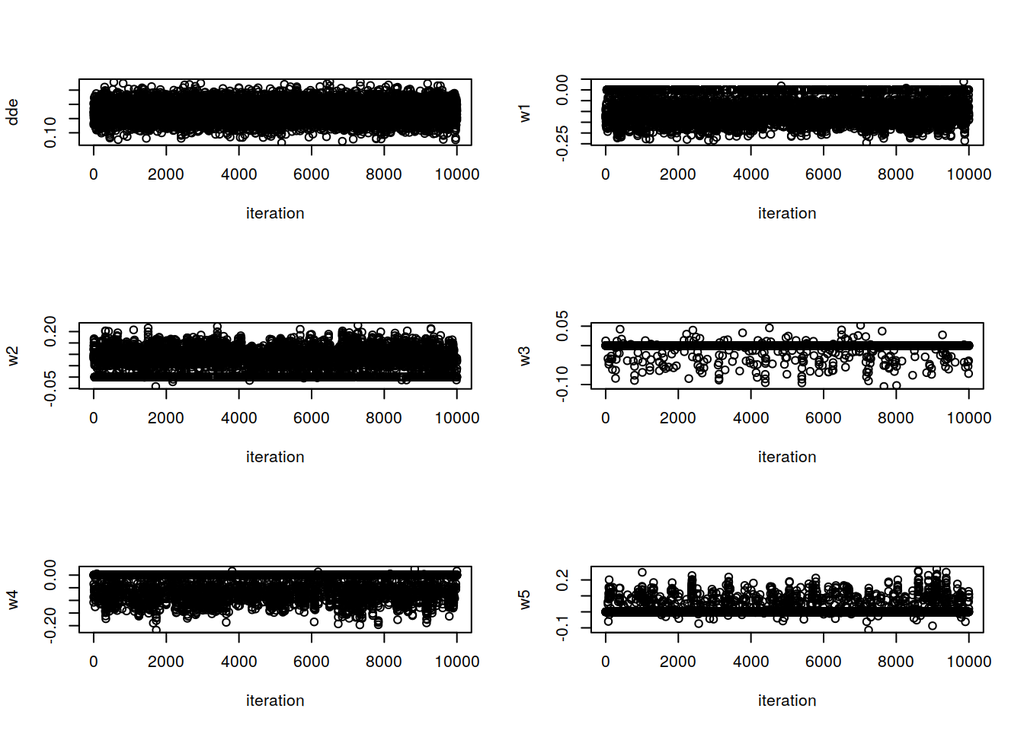

```r
par(mfrow=c(3,2))
ylb=c("intercept","dde","w1","w2","w3","w4","w5")
for(j in 2:7){
  #print(j)
  plot(beta[,j],xlab="iteration",ylab=ylb[j])
}
```

## 4.5 Resultados

La grafica de la curva de respuesta a DDE para nacimiento prematuro es ahora:

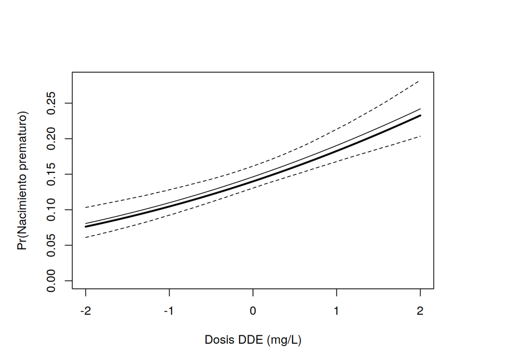

```r
par(mfrow=c(1,1))
par(mar=c(5,5,5,5))
xg<- seq(-2,2,length=100)   # Grid
beta<- beta[1001:nrow(beta),]   # Excluyendo el periodo de calentamiento
post<- matrix(0,100,4)
for(i in 1:100){
  post[i,1]<- mean(pnorm(beta[,1] + xg[i]*beta[,2]))
  post[i,2:3]<- quantile(pnorm(beta[,1] + xg[i]*beta[,2]),probs=c(0.025,0.975))
  post[i,4]<- pnorm(-1.08068 + xg[i]*0.17536139)
}
xtrue<- xg*sqrt(var(dde$x)) + mean(dde$x)
plot(xtrue,post[,1],xlab="Dosis DDE (mg/L)",ylab="Pr(Nacimiento prematuro)",cex=1.2,
     ylim=c(0,max(post)), type="l")
lines(xtrue,post[,2],lty=2)
lines(xtrue,post[,3],lty=2)
lines(xtrue,post[,4],lwd=2.5)
```

### 4.5.1 Resumen

La tabla resumen de los coeficientes de regresion incluye:

- media posterior
- mediana
- desviacion estandar
- 95% intervalo de confianza
- Pr(beta_j=0|datos)

Esta informacion se almacena en el archivo `est46114_s16_beta_ss_summary.csv`.

```r
table1<- matrix(0,7,6)
for(i in 1:7){
  table1[i,]<- c(mean(beta[,i]),median(beta[,i]),sqrt(var(beta[,i])),
                 quantile(beta[,i],probs=c(0.025,0.975)),
         length(beta[beta[,i]==0,i])/nrow(beta))
}
table1<- round(table1*100)/100
write(t(table1),file='est46114_s16_beta_ss_summary.csv',ncol=6)
head(table1)
```

```
##       [,1]  [,2] [,3]  [,4]  [,5] [,6]
## [1,] -1.05 -1.05 0.03 -1.12 -0.99 0.00
## [2,]  0.18  0.18 0.03  0.12  0.23 0.00
## [3,] -0.07 -0.08 0.06 -0.18  0.00 0.39
## [4,]  0.05  0.00 0.05  0.00  0.15 0.53
## [5,]  0.00  0.00 0.01  0.00  0.00 0.97
## [6,] -0.02  0.00 0.04 -0.13  0.00 0.76
```

### 4.5.2 Probabilidades de los modelos

```r
Mout <- beta
Mout <- matrix(as.numeric(I(Mout==0)),nrow(Mout),ncol(Mout))
Mindex <- Mout[1,]
ind<- function(m1,m2){
  as.numeric(all(I(m1==m2)))
}
Im<- apply(Mout,1,ind,m2=Mout[1,]) # Indicadora para las muestras del primer modelo
Nm<- sum(Im)                       # Numero de muestral del primer modelo
Mout<- Mout[Im==0,]
repeat{
  if(length(Mout)==7) Mout<- matrix(Mout,1,7)
  Mindex <- rbind(Mindex,Mout[1,])
  Im <- apply(Mout,1,ind,m2=Mout[1,])
  Nm <- c(Nm,sum(Im))
  #print(sum(Nm))
  if(sum(Nm)==nrow(beta)){
    break
  } else Mout<- Mout[Im==0,]
}
#   Ordenando los modelos visitados en terminos de sus probabilidades (ordendecreciente)
Pm <- Nm/sum(Nm)
ord <- order(Pm)
Pm <- Pm[rev(ord)]
Mindex <- Mindex[rev(ord),]
table2 <- cbind(Pm,Mindex)
write(t(table2),file='est46114_s16_beta_ss_pmodel.csv',ncol=8)
```

# 5 Discusion

## 5.1 Comentarios

- El modelo de seleccion estocastica automatizada de variables es util cuando deseamos hacer inferencia sobre los modelos contendientes en gran escala.
- La implementacion MCMC hace uso de la `inclusion de variables latentes` (procedimiento usualmente referido como `data augmentation` [vinculo](http://cs231n.stanford.edu/reports/2017/pdfs/300.pdf)).

## 5.2 Lecturas complementarias

- George, *Bayesian Stochastic Search Variable Selection*. [Vinculo](http://www-stat.wharton.upenn.edu/~edgeorge/Research_papers/fastN96.pdf)
- van Dyk and Meng, *The art of Data Augmentation*. [Vinculo](http://www.stat.harvard.edu/Faculty_Content/meng/JCGS01.pdf).